# Tarea 1

Carolina Morales

20/09/2019

## Preparación de datos

En primer lugar, procedí a cargar y modificar los datos de avistamientos de objetos voladores no identificados (UFO) recolectados originalmente por la NUFORC. La modificacion de la planilla consistió en la adición de columnas de manera que los datos pudieran ser trabajables. Además. establecí el criterio de mantener los avistamientos de duración menor a un dia.

*Para más información acerca de este dataset, visitar https://github.com/rfordatascience/tidytuesday/tree/master/data/2019/2019-06-25.*

## Información por País

En la **Figura 1** se muestra el número de avistamientos de UFO por pais. La nación que más observaciones tiene es EEUU, con 65114 avistamientos Por el contrario, el pais que menos observaciones tiene es Alemania con 105 avistamientos.

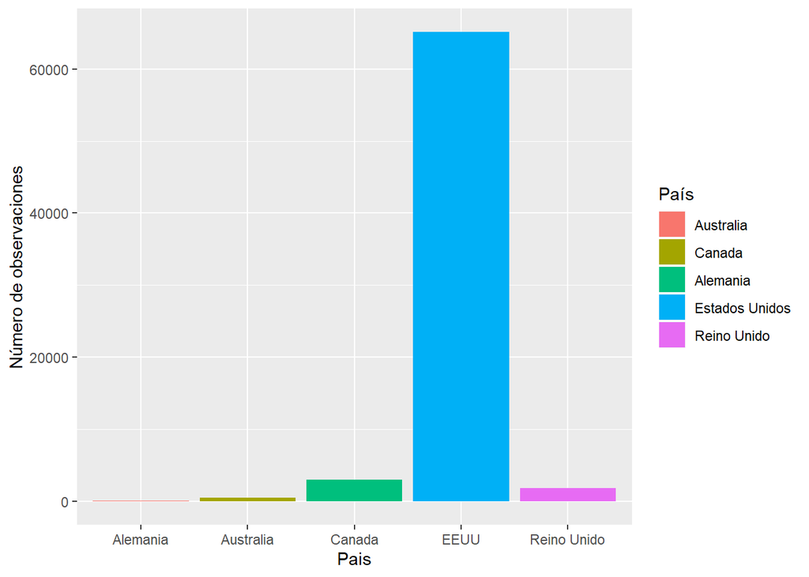

**Figura 1 Avistamientos de UFO por país.** Se muestra el total de avistamientos registrados por país en el periodo de tiempo considerado para el estudio.

En la **Figura 2** se muestra la dinámica por país del número de observaciones por año, en el periodo de comprendido entre los años 1998 y 2014. El peak de observaciones corresponde a 6879 para EEUU en el año 2012

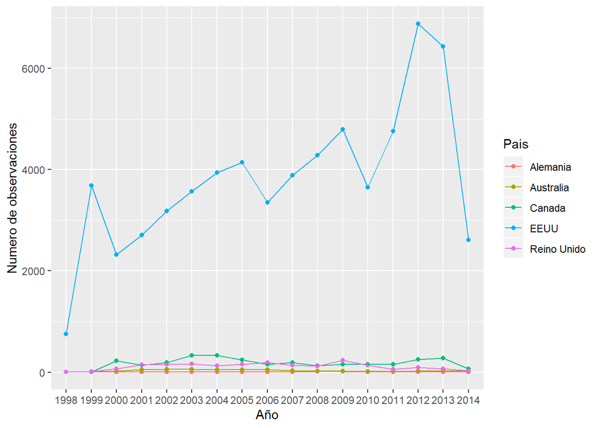

**Figura 2 Dinámica de avistamientos por país.** Se muestra la evolución de los avistamientos entre los años 1998 y 2014 para todos los paíces estudiados.

## Tabla resumen

Finalmente, la **Tabla 1** resume las observaciones registradas a lo largo del periodo de tiempo para cada país.

Tabla 1: Avistamientos de UFO entre los años 1998 y 2014 para los cinco paices en estudio

| Year | Alemania | Australia | Canada | EEUU | Reino Unido |
| --- | --- | --- | --- | --- | --- |
| 1998 | NA | 7 | NA | 752 | 4 |
| 1999 | 4 | 14 | 5 | 3681 | 16 |
| 2000 | 2 | 21 | 228 | 2320 | 68 |
| 2001 | 7 | 45 | 140 | 2712 | 145 |
| 2002 | 4 | 59 | 190 | 3185 | 152 |
| 2003 | 6 | 56 | 330 | 3573 | 165 |
| 2004 | 5 | 51 | 330 | 3943 | 130 |
| 2005 | 5 | 51 | 243 | 4144 | 155 |
| 2006 | 6 | 51 | 154 | 3347 | 188 |
| 2007 | 9 | 35 | 191 | 3886 | 137 |
| 2008 | 13 | 25 | 129 | 4281 | 120 |
| 2009 | 11 | 19 | 152 | 4798 | 236 |
| 2010 | 6 | 12 | 151 | 3650 | 133 |
| 2011 | 4 | 18 | 151 | 4757 | 62 |
| 2012 | 8 | 21 | 255 | 6879 | 93 |
| 2013 | 9 | 30 | 275 | 6434 | 63 |
| 2014 | 4 | 20 | 70 | 2614 | 28 |

Note:  
NA = no existen registros

[output not shown]